# Activity Analysis

Krupa

Sunday, July 19, 2015

## Reproducible Research: Peer Assessment 1

This assignment makes use of data from a personal activity monitoring device. This device collects data at 5 minute intervals throughout the day. The data consists of two months of data from an anonymous individual collected during the months of October and November, 2012 and include the number of steps taken in 5 minute intervals each day.

### Data

The data provided for the assignment is stored in a comma-separated-value (CSV) file and there are a total of 17,568 observations in this dataset. The variables included in this dataset are:

- **steps**: Number of steps taking in a 5-minute interval (missing values are coded as NA)
- **date**: The date on which the measurement was taken in YYYY-MM-DD format
- **interval**: Identifier for the 5-minute interval in which measurement was taken

### Loading and preprocessing the data

Set current working directory where the downloaded file exists

```r
setwd("D:/Data specialist course/Reproducible research/Peer Review")
#
#Unzip the datafile and read it to a data set with name ActivityData
#
unzip("repdata-data-activity.zip", "activity.csv")
ActivityData <- read.csv("activity.csv", colClasses = c("numeric", "character", "numeric"))
names(ActivityData)
```

```
## [1] "steps"    "date"     "interval"
```

```r
# convert date to date data type
ActivityData$date <- as.Date(ActivityData$date)
# Display top 6 records
head(ActivityData)
```

```
##   steps       date interval
## 1    NA 2012-10-01        0
## 2    NA 2012-10-01        5
## 3    NA 2012-10-01       10
## 4    NA 2012-10-01       15
## 5    NA 2012-10-01       20
## 6    NA 2012-10-01       25
```

### Calculating Mean total number of steps taken per day

#### 1. Calculate the total number of steps taken per day, ignoring the NA values

```r
StepsPerDay<- aggregate(steps ~ date, ActivityData, sum)
```

#### 2. Create histogram of the total number of steps taken each day

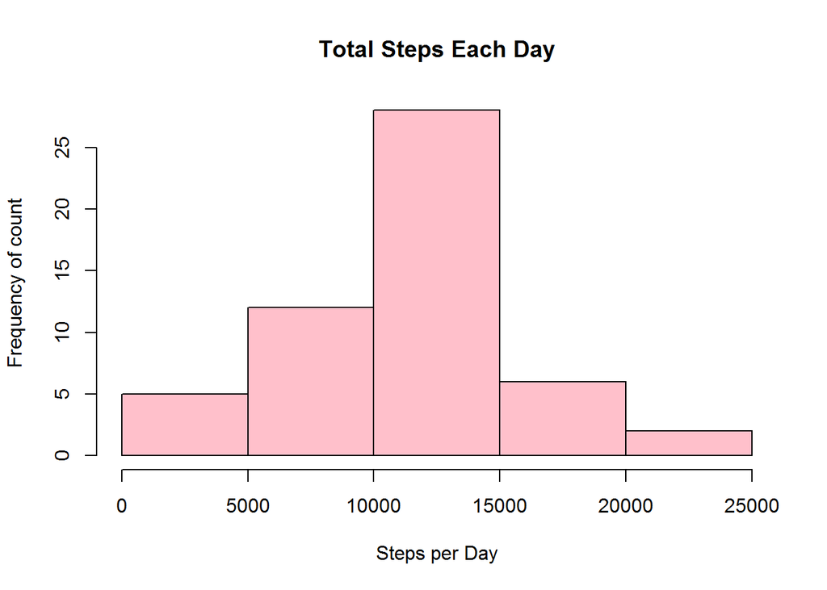

```r
hist(StepsPerDay$steps, main = c("Total Steps Each Day"), col="pink", xlab="Steps per Day",ylab="Frequency of count" )
```

#### 3.Calculate and report the mean and median of the total number of steps taken per day

```r
mean(StepsPerDay$steps)
```

```
## [1] 10766.19
```

```r
median(StepsPerDay$steps)
```

```
## [1] 10765
```